# Notebook 03: Classification and Logistic Regression

```r
library(tidyverse)
library(forcats)
library(ggrepel)
library(smodels)

theme_set(theme_minimal())
options(dplyr.summarise.inform = FALSE)
options(width = 77L)
```

## NBA Dataset

Today we are going to look at a dataset based on attempted shots in the NBA. Specifically, using features based on when and where the shot was taken, we want to predict whether or not the shot was successful.

```r
set.seed(1)

nba <- read_csv("data/nba_shots.csv") %>%
  mutate(train_id = if_else(runif(n()) < 0.6, "train", "valid"))
nba
```

```
## # A tibble: 20,000 x 12
##      fgm period shot_clock dribbles touch_time shot_dist pts_type
##    <dbl>  <dbl>      <dbl>    <dbl>      <dbl>     <dbl>    <dbl>
##  1     0      2       18.6        0        0.8      23.7        2
##  2     0      4       11          0        1.2      26.7        3
##  3     0      3        4.9        2        1.8       9.4        2
##  4     0      4        2          3        3.1      24.3        2
##  5     0      4        9.9        4        3.9      14.6        2
##  6     1      3       12.7        6        6.7       9.1        2
##  7     0      1        3.1        4        5.9       3.5        2
##  8     0      2       24          2        4.2      35.2        3
##  9     0      3       19.8        0        0.7      22.7        3
## 10     0      4       11.6        2        3.2       3.9        2
## # … with 19,990 more rows, and 5 more variables: close_def_dist <dbl>,
## #   shooter_height <dbl>, defender_height <dbl>, player_name <chr>,
## #   train_id <chr>
```

Notice that the response of interest is coded as either `0` (shot missed) or `1` (shot made).

### Linear Regression

We can apply a simple linear regression to this prediction task. To start, I will use only the variables `shot_clock` and `shot_dist`.

```r
model <- nba %>%
  filter(train_id == "train") %>%
  lm(fgm ~ shot_clock + shot_dist, data = .)

summary(model)
```

```
##
## Call:
## lm(formula = fgm ~ shot_clock + shot_dist, data = .)
##
## Residuals:
##     Min      1Q  Median      3Q     Max
## -0.7093 -0.4633  0.2947  0.4654  0.8081
##
## Coefficients:
##               Estimate Std. Error t value Pr(>|t|)
## (Intercept)  0.5538102  0.0135470  40.881   <2e-16 ***
## shot_clock   0.0066012  0.0007786   8.478   <2e-16 ***
## shot_dist   -0.0098541  0.0005091 -19.355   <2e-16 ***
## ---
## Signif. codes:  0 '***' 0.001 '**' 0.01 '*' 0.05 '.' 0.1 ' ' 1
##
## Residual standard error: 0.4894 on 12018 degrees of freedom
## Multiple R-squared:  0.04229,    Adjusted R-squared:  0.04214
## F-statistic: 265.4 on 2 and 12018 DF,  p-value: < 2.2e-16
```

Plotting the predicted values we see a reasonable pattern:

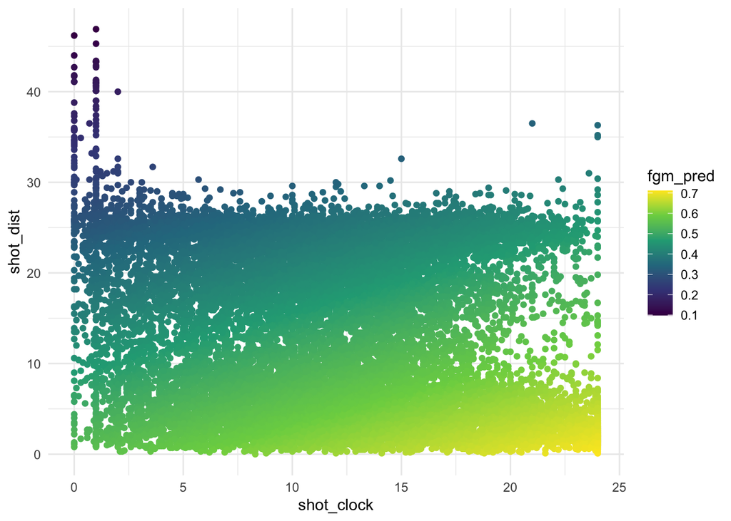

```r
nba %>%
  mutate(fgm_pred = predict(model, newdata = .)) %>%
  ggplot(aes(shot_clock, shot_dist)) +
    geom_point(aes(color = fgm_pred)) +
    scale_color_viridis_c()
```

Think for a moment about exactly what the predicted value might mean here. If it is 1, the model predicts that the shot will be made and if 0 the model predicts it will not be made. What about 0.5? Here, it seems like there is an equal chance of the shot missing or being made. Extrapolating, we can see the predicted value as a predicted probability.

We can change the plot to show exactly where we believe a shot is more likely to miss versus where it is more likely to be made:

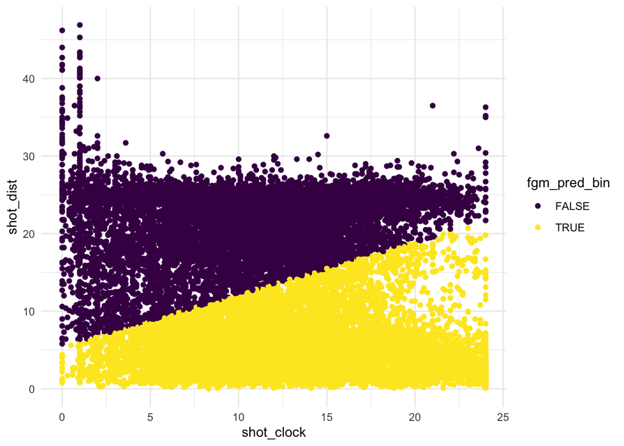

```r
nba %>%
  mutate(fgm_pred = predict(model, newdata = .)) %>%
  mutate(fgm_pred_bin = (fgm_pred > 0.5)) %>%
  ggplot(aes(shot_clock, shot_dist)) +
    geom_point(aes(color = fgm_pred_bin)) +
    scale_color_viridis_d()
```

Notice that, because this is a linear model, the separation between the two regions is given by a straight line.

### Classification rate

The variable we are trying to predict here is quite different from all of our previous examples. It takes on only one of two values. In cases like this (such as a spam classifier or cancer detection algorithm), as we have just seen, it is possible to ignore this distinction when fitting a model by treating one category as a `0` and the other category as a `1`. Next time, we’ll see what to do when we have more than two categories.

When our response takes on only a small set of values, particularly if these are un-ordered, we say that we are doing **classification**. Somewhat confusingly, the complement of classification is often called **regression**. I try to avoid this later term because it can become confusing with the more general notion of regression models.

It is possible to use RMSE to measure how well our predicted probabilities fit the data. Often though, we ultimately do not care much about the probabilities, and simple want to make the binary guess of our model be correct as often as possible. Here, we would only allow for predictions to be either `0` or `1`. The best metric for measuring this is the *classification rate*, the proportion of guesses that were correct. We can measure that here fairly quickly:

```r
nba %>%
  mutate(fgm_pred = as.numeric(predict(model, newdata = .) > 0.5)) %>%
  group_by(train_id) %>%
  summarize(class_rate = mean(fgm == fgm_pred))
```

```
## # A tibble: 2 x 2
##   train_id class_rate
##   <chr>         <dbl>
## 1 train         0.582
## 2 valid         0.584
```

```r
nba %>%
  mutate(fgm_pred = as.numeric(predict(model, newdata = .) > 0.5)) %>%
  select(fgm, fgm_pred, train_id) %>%
  table()
```

```
## , , train_id = train
##
##    fgm_pred
## fgm    0    1
##   0 3564 2424
##   1 2598 3435
##
## , , train_id = valid
##
##    fgm_pred
## fgm    0    1
##   0 2363 1649
##   1 1668 2299
```

This type of table is useful to see what kinds of errors are we making. It becomes particularly useful when working with more than two categories.

## Generalized Linear Models

Generalized linear models (GLMs) extend the linear model assumptions to allow for a more complex relationship between Y and X. The linear part that is preserved, is that X is always multiplied (as a matrix) by the unknown parameters beta. For example:

$$g\left[ \text{mean} (Y) \right] = X \beta$$

The most commonly seen GLM relates the *log odds ratio* to the linear predictor:

$$\text{logit}\left[\text{mean} (Y) \right] = \log \left( \frac{\text{mean} (Y)}{1 - \text{mean} (Y)} \right) = X \beta$$

There are a number of justifications for using the log odds. The easiest to explain is that the odds ratio can be any non-negative value and therefore the logarithm of the odds ratio can be any real number. This makes it reasonable to assume that the log odds could be represented by X beta. There are more technical reasons for using this particular function, the logit, having to do with the theory of exponential families.

A GLM using the logit function is so common that it has its own name: *logistic regression*.

Once we have learned the regression vector in logistic regression, we can get predicted probabilities using the inverse logit function:

$$\text{mean} (Y) = \text{logit}^{-1} (X \beta)$$

### GLMs in R

To git a generalized linear model in R, we replace the `lm` function for the `glm` function. With no other changes, the learned model parameters will be exactly the same as before. If we set the `family` parameter to `binomial` we will get logistic regression:

```r
model <- nba %>%
  filter(train_id == "train") %>%
  glm(fgm ~ shot_clock + shot_dist, data = ., family = binomial)

summary(model)
```

```
##
## Call:
## glm(formula = fgm ~ shot_clock + shot_dist, family = binomial,
##     data = .)
##
## Deviance Residuals:
##     Min       1Q   Median       3Q      Max
## -1.5609  -1.1146   0.8432   1.1185   1.7431
##
## Coefficients:
##              Estimate Std. Error z value Pr(>|z|)
## (Intercept)  0.212944   0.056039   3.800 0.000145 ***
## shot_clock   0.027780   0.003274   8.486  < 2e-16 ***
## shot_dist   -0.040452   0.002137 -18.928  < 2e-16 ***
## ---
## Signif. codes:  0 '***' 0.001 '**' 0.01 '*' 0.05 '.' 0.1 ' ' 1
##
## (Dispersion parameter for binomial family taken to be 1)
##
##     Null deviance: 16664  on 12020  degrees of freedom
## Residual deviance: 16148  on 12018  degrees of freedom
## AIC: 16154
##
## Number of Fisher Scoring iterations: 4
```

When using the `predict` function, you need to be careful to select the option `type = "response"`. Otherwise, R will return the values X beta, without applying the inverse logit function.

```r
nba %>%
  mutate(fgm_pred = predict(model, newdata = ., type = "response")) %>%
  select(fgm, fgm_pred)
```

```
## # A tibble: 20,000 x 2
##      fgm fgm_pred
##    <dbl>    <dbl>
##  1     0    0.443
##  2     0    0.363
##  3     0    0.492
##  4     0    0.329
##  5     0    0.474
##  6     1    0.549
##  7     0    0.539
##  8     0    0.367
##  9     0    0.461
## 10     0    0.593
## # … with 19,990 more rows
```

The predicted values seem very similar to those given by the linear regression from before:

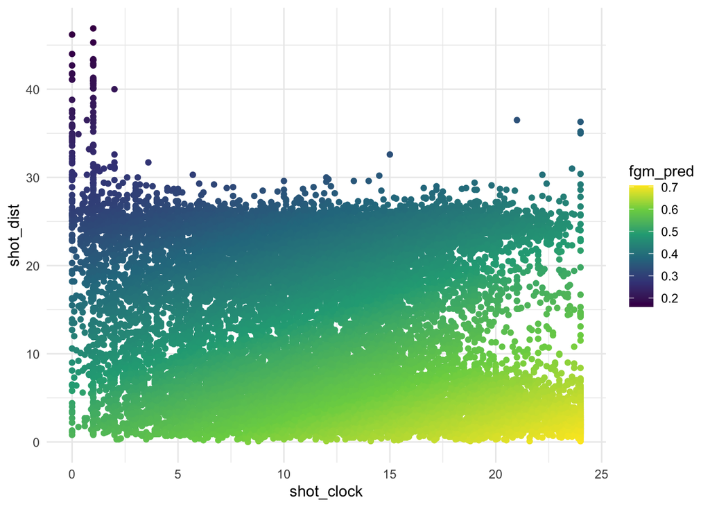

```r
nba %>%
  mutate(fgm_pred = predict(model, newdata = ., type = "response")) %>%
  ggplot(aes(shot_clock, shot_dist)) +
    geom_point(aes(color = fgm_pred)) +
    scale_color_viridis_c()
```

And the two classes seem virtually the same as before as well:

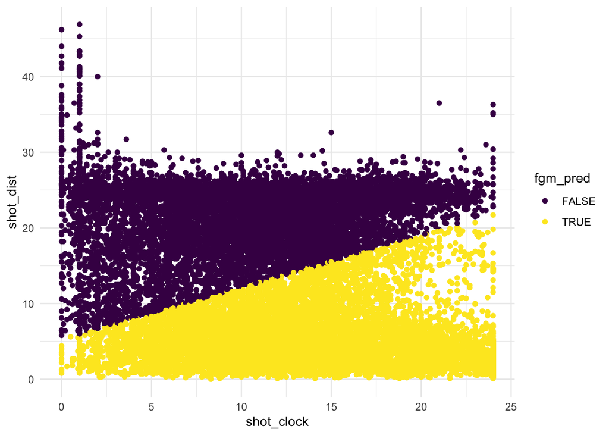

```r
nba %>%
  mutate(fgm_pred = predict(model, newdata = ., type = "response")) %>%
  mutate(fgm_pred = (fgm_pred > 0.5)) %>%
  ggplot(aes(shot_clock, shot_dist)) +
    geom_point(aes(color = fgm_pred)) +
    scale_color_viridis_d()
```

### GLM and LM comparison

Visually, it looks like the output of the GLM and LM are not very different. Let’s formalize that here by saving the predicted classes from both:

```r
model_lm <- nba %>%
  filter(train_id == "train") %>%
  lm(fgm ~ shot_clock + shot_dist, data = .)

model_glm <- nba %>%
  filter(train_id == "train") %>%
  glm(fgm ~ shot_clock + shot_dist, data = ., family = binomial)
```

Here we see that only a handful of points right on the boundary differ between the models:

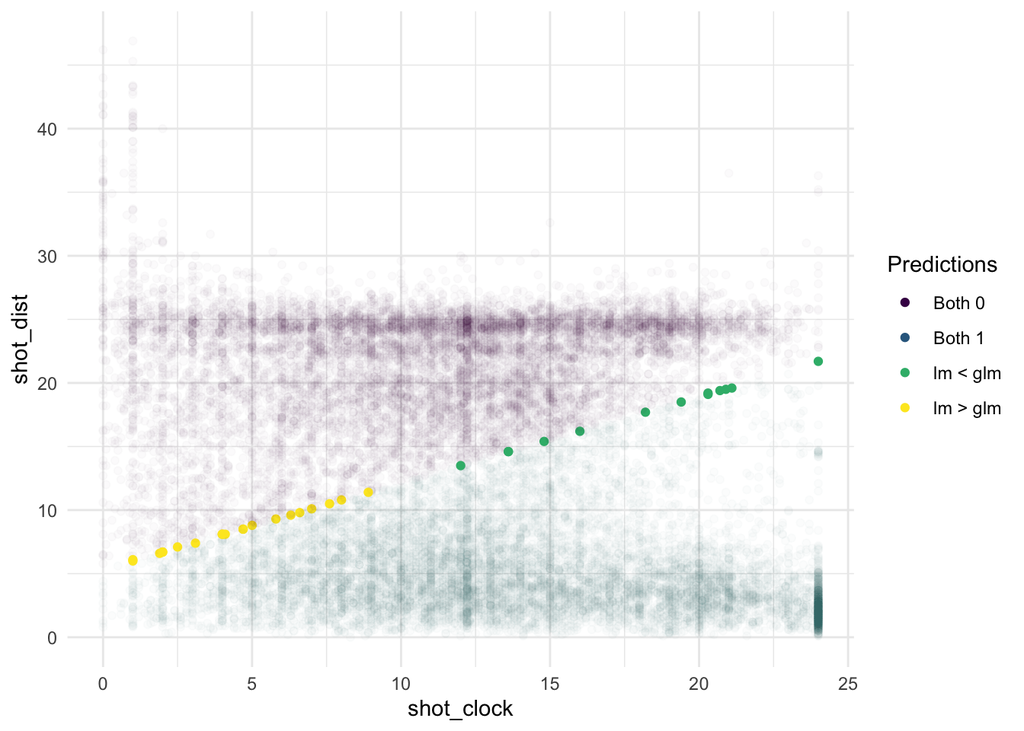

```r
nba %>%
  mutate(fgm_pred_lm = as.numeric(predict(model_lm, newdata = .) > 0.5)) %>%
  mutate(fgm_pred_glm = as.numeric(
    predict(model_glm, newdata = ., type = "response") > 0.5)
  ) %>%
  arrange(nba, fgm_pred_lm != fgm_pred_glm) %>%
  mutate(class = if_else(fgm_pred_lm == 1 & fgm_pred_glm == 1, "Both 1", "other")) %>%
  mutate(class = if_else(fgm_pred_lm == 0 & fgm_pred_glm == 0, "Both 0", class)) %>%
  mutate(class = if_else(fgm_pred_lm == 1 & fgm_pred_glm == 0, "lm > glm", class)) %>%
  mutate(class = if_else(fgm_pred_lm == 0 & fgm_pred_glm == 1, "lm < glm", class)) %>%
  mutate(alpha = if_else(fgm_pred_lm == fgm_pred_glm, 0.02, 1)) %>%
  ggplot(aes(shot_clock, shot_dist)) +
    geom_point(aes(color = class, alpha = alpha)) +
    scale_color_viridis_d() +
    scale_alpha_identity() +
    labs(color = "Predictions")
```

Similarly, even the predicted probabilities seem very similar.

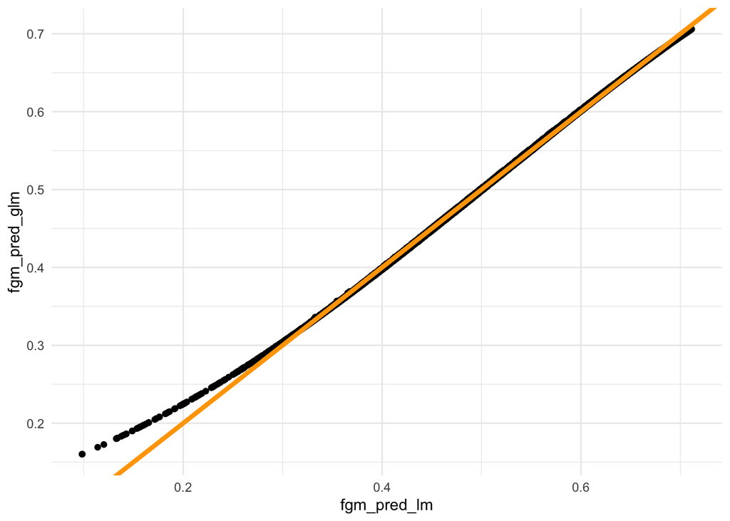

```r
nba %>%
  mutate(fgm_pred_lm = predict(model_lm, newdata = .)) %>%
  mutate(fgm_pred_glm = predict(model_glm, newdata = ., type = "response")) %>%
  ggplot(aes(fgm_pred_lm, fgm_pred_glm)) +
    geom_point() +
    geom_abline(aes(intercept = 0, slope = 1), color = "orange", size = 1.5)
```

We see that the greatest difference comes from very low probability shots. This is a general categorization of the difference between logistic and linear regression for classification tasks. Typically the only differences arise when we have extreme probabilities. If most of the predicted values fall within the same range, the linear model provides a good approximation. In most cases, I do not see a large difference between the two models from a predictive standpoint. In some cases, particularly when dealing with relatively rare events, logistic regression offers better predictions. However, this comes at a cost of a slower run time.